# CA2-EP0302FT02-P2340656-YeYintAung

# ASEAN analysis

Let's begin by examining the origin of refugees in ASEAN. The pie chart reveals that Vietnam and Myanmar are the two main contributors to the refugee population in ASEAN. According to the line chart, the data fluctuate consistently, suggesting that the political and economic situations in these two countries are in a state of flux.

Based on the research I conducted, the significant increase in the refugee population in Vietnam can be attributed to the end of the Vietnam War from 1975 to 1995. During this period, over three million people fled from Vietnam, Laos, and Cambodia. Many faced perilous journeys at sea, falling victim to pirates or traveling on overcrowded, makeshift boats. Those fortunate enough reached refugee camps in Thailand, Malaysia, or the Philippines. Eventually, more than 2.5 million refugees were resettled globally, with over a million finding refuge in the United States.

As for Myanmar, the surge in refugees after 1990 is linked to the uprising that began on August 8, 1988. This uprising originated from conflicts between the public and armed police, resulting in thousands of deaths attributed to the military. While Burmese authorities estimate around 350 people killed during this period, the Rohingya Genocide and the military coup account for the refugee influx over the past decade.

Regarding the countries where refugees seek asylum, Thailand and Malaysia are the primary destinations. Thailand, being the neighbor to both Vietnam and Myanmar, serves as a logical choice. In the case of Malaysia, there is a noticeable and rapid growth in asylum population, particularly from the year 2000 onwards.

Ref.

How the end of the Vietnam War led to a refugee crisis (no date) History.com. Available at: https://www.history.com/news/vietnam-war-refugees (Accessed: 02 February 2024). 8888 uprising (2023) Wikipedia. Available at: https://en.wikipedia.org/wiki/8888_Uprising (Accessed: 02 February 2024). Rohingya genocide (2024) Wikipedia. Available at: https://en.wikipedia.org/wiki/Rohingya_genocide (Accessed: 02 February 2024).

In conclusion, the patterns observed in the origin and asylum-seeking behavior of refugees within my analysis show that a commonality—refugees predominantly originate from countries or territories grappling with either economic or political instability. The decision to abandon one's homeland and seek refuge in foreign lands is undoubtedly rooted in compelling and often dire circumstances. The intricate interplay of political unrest, economic hardships, and, in some instances, historical events such as the end of wars or uprisings, underscores the complex motivations behind these mass movements of people.

These findings underscore the pressing need for international attention and collaborative efforts to address the root causes of instability in these regions. It is essential to recognize the human stories behind the data, acknowledging the resilience of those forced to leave their homes and the challenges they face in adapting to new environments. By understanding the multifaceted factors influencing refugee movements, we can work towards creating more effective and compassionate solutions to support those who have sought refuge in foreign lands. Ultimately, fostering stability and security in the countries of origin remains crucial in mitigating the plight of refugees and creating a more just and equitable global community.

Thanks

# RQ 2

To what extent does HDB resale price vary with changes in location, storey, number of rooms, square footage, and floor area?

```python
import pandas as pd

# Define the file path for HDB resale data
resalesFilePath = 'HDB resales/ResaleflatpricesbasedonregistrationdatefromJan2017onwards.csv'

# Read the HDB resale data into a DataFrame
df_resale = pd.read_csv(resalesFilePath)

# Check if the DataFrame for HDB resales is not empty
if not df_resale.empty:
    # Display header for HDB resale dataset
    print(f'{"*"*120}')
    print(f'{("HDB Resale Flat Prices from Jan 2017 Onwards"):^120}')
    print(f'{"*"*120}')

    # Display loading success message
    print(f'Successfully loaded data from {resalesFilePath}')

    # Display shape, index, column names, non-null values count, and data types
    print(f'Shape of the HDB resale dataset: {df_resale.shape}\n')
    print(f'Index of the HDB resale dataset: {df_resale.index}\n')
    print(f'Column names:\n{df_resale.columns}\n')

    non_na_count = df_resale.count()
    print(f'Total number of non-null values in the HDB resale dataset:\n{non_na_count}\n')

    print(f'Data types of each column:\n{df_resale.dtypes}\n')

    print(f'Statistical summary of the HDB resale data set:\n{df_resale.describe()}')

    # Displaying a small part of the HDB resale dataset
    print(f'First 5 rows of the HDB resale dataset:\n{df_resale.head()}\n\n')
print('\nThis data set is from 2017 January to 2024 February')
```

```
                                      HDB Resale Flat Prices from Jan 2017 Onwards
Successfully loaded data from HDB resales/ResaleflatpricesbasedonregistrationdatefromJan2017onwards.csv
Shape of the HDB resale dataset: (171883, 11)

Index of the HDB resale dataset: RangeIndex(start=0, stop=171883, step=1)

Column names:
Index(['month', 'town', 'flat_type', 'block', 'street_name', 'storey_range',
       'floor_area_sqm', 'flat_model', 'lease_commence_date',
       'remaining_lease', 'resale_price'],
      dtype='object')

Total number of non-null values in the HDB resale dataset:
month                  171883
town                   171883
flat_type              171883
block                  171883
street_name            171883
storey_range           171883
floor_area_sqm         171883
flat_model             171883
lease_commence_date    171883
remaining_lease        171883
resale_price           171883
dtype: int64

Data types of each column:
month                   object
town                    object
flat_type               object
block                   object
street_name             object
storey_range            object
floor_area_sqm         float64
flat_model              object
lease_commence_date      int64
remaining_lease         object
resale_price           float64
dtype: object

```

[output cut: 20 more lines]

```
1            67.0  New Generation                 1978  60 years 07 months
2            67.0  New Generation                 1980  62 years 05 months
3            68.0  New Generation                 1980   62 years 01 month
4            67.0  New Generation                 1980  62 years 05 months

   resale_price
0     232,000.0
1     250,000.0
2     262,000.0
3     265,000.0
4     265,000.0



This data set is from 2017 January to 2024 February
```

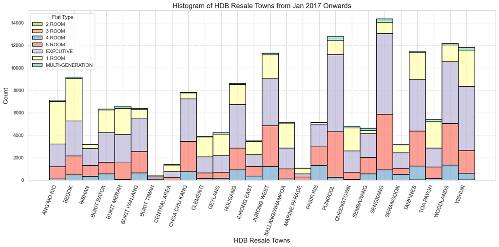

```python
# Create a copy of df_resale
df_town_room = df_resale.copy()

# Set the style for the plot
sns.set(style="whitegrid")

# Create a histogram using Seaborn with added features
plt.figure(figsize=(16, 8))

# Use histplot with multiple="stack" for more control over the appearance
plot = sns.histplot(df_town_room, x='town', bins=30, kde=False, hue='flat_type',
                    palette='Set3', edgecolor='black', linewidth=1.2, multiple="stack")

# Set plot labels and title
plt.xlabel('HDB Resale Towns', fontsize=15)
plt.ylabel('Count', fontsize=14)
plt.title('Histogram of HDB Resale Towns from Jan 2017 Onwards', fontsize=16)

# Rotate x-axis labels for better readability
plt.xticks(rotation=70, ha='right', fontsize=12)

# Add a legend for better understanding of hue
legend_labels = df_town_room['flat_type'].unique()
plot.legend(title='Flat Type', labels=legend_labels)

# Add a grid for better visibility
plt.grid(axis='y', linestyle='--', alpha=0.7)

# Adjust the spacing between bars
plt.tight_layout()

# Show the plot
plt.show()
```

# Analysis of HDB resales location among investor or buyer

From the histogram, we observe that Sengkang has recorded the highest number of HDB sales, exceeding 14,000 units from 2017 to 2024. This figure surpasses the second-ranking area, Punggol, by nearly 2,000 units. The primary reasons for this outstanding performance can be attributed to Sengkang's urban appeal to Singapore's youth. The district is currently undergoing significant population expansion and commercial development, driven by the Singaporean government's enhancements to the transit system and job prospects in the area.

Conversely, the areas with the lowest HDB sales are Bukit Timah, Central Area, and Marine Parade. Research indicates that the limited sales data in these regions can be attributed to the reluctance of property owners to sell their units. These areas are considered lucrative investments, and the property prices are deemed too high for the majority of potential buyers.Additionally, it is worth noting that the government is planning further development in Bukit Timah. Ref.

Rchan (2023a) Singapore’s perfect ten development on Bukit Timah Road is primed for opulent living, Robb Report Malaysia. Available at: https://robbreport.com.my/2023/03/31/perfect-ten-development-bukit-timah-road-singapore/ (Accessed: 02 February 2024).

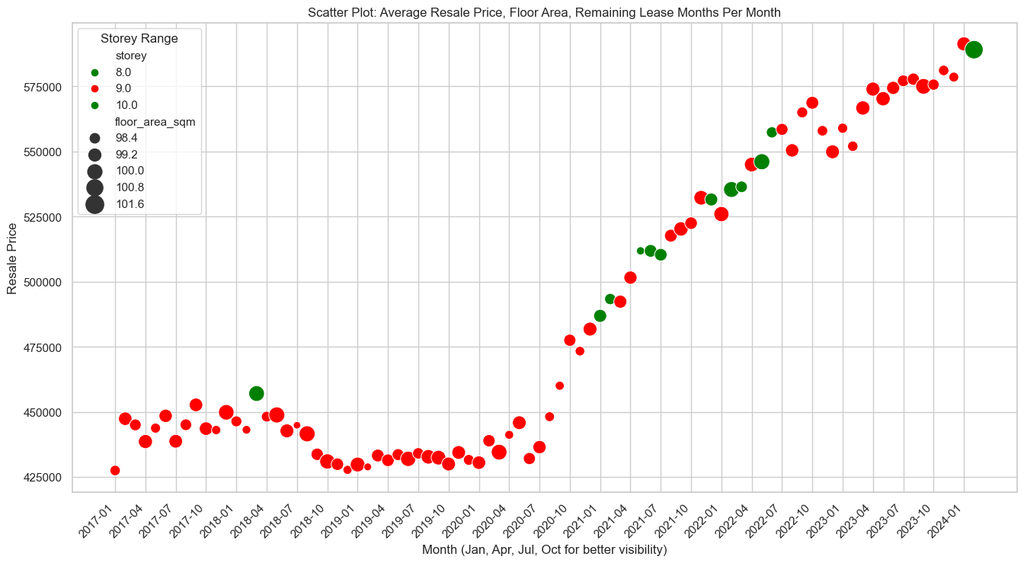

```python
import re
import seaborn as sns
import matplotlib.pyplot as plt
import numpy as np

# Create a new DataFrame with selected columns
df_lease_area_price = df_resale[['resale_price', 'month']].copy()

df_lease_area_price['storey'] = df_resale['storey_range'].apply(lambda x: int(x[-2:])).copy()

# Generate random values for 'floor_area_sqm'
df_lease_area_price['floor_area_sqm'] = np.random.randint(50, 150, size=len(df_lease_area_price))

df_lease_area_price = df_lease_area_price.set_index('month')

# Group by 'month' and calculate the average for each column
average_by_month = df_lease_area_price.groupby('month').mean()

average_by_month['storey'] = average_by_month['storey'].apply(np.floor)

color = ["green", "Red", "Green"]
sns.set_palette(color)

# Set the style for the plot
sns.set(style="whitegrid")

# Scatter plot with Seaborn
plt.figure(figsize=(16, 8))
scatter = sns.scatterplot(
    x=average_by_month.index,
    y='resale_price',
    size='floor_area_sqm',
    hue='storey',
    data=average_by_month,
    palette=color,  # Adjust colormap
    sizes=(50, 300),  # Adjust marker sizes
)

# Set labels and title
plt.xlabel('Month (Jan, Apr, Jul, Oct for better visibility)')
plt.ylabel('Resale Price')
plt.title('Scatter Plot: Average Resale Price, Floor Area, Remaining Lease Months Per Month')

# Set x-axis ticks for Jan, Apr, Jul, and Oct
plt.xticks([month for month in average_by_month.index if month.endswith(('01', '04', '07', '10'))], rotation=45, ha='right')

# Customize legend
legend = plt.legend(title='Storey', loc='upper left')
legend.set_title('Storey Range')

# Show the plot
plt.show()
```